# Reduce Summer GAMs

Ryan Hankins

# Starting models:

Summer Model

Model 1: Summer Chla ~ s(logNH4) + s(logPO4) + s(log(NO2+NO3)) + s(temperature) + s(logconductivity) + Sac Valley index + previous year(Sac Valley index) + s(Region:logSAC) + s(Region:logSJ)+ s(Region:Exports) + Pre/post-clam + s(Region:lag(logSAC)) + s(Region:lag(logSJ)) + lag(logNH4) + s(lag(PO4)) + s(lag(logNO2+NO3)) + (1|Month)

Model 2: Summer Chla ~ s(logNH4) + s(logPO4) + s(log(NO2+NO3)) + s(temperature) + s(logconductivity) + Sac Valley index + previous year(Sac Valley index) + Pre/post-clam + s(lag(logNDOI)) + s(Region:log(NDOI)) + lag(logNH4) + s(lag(PO4)) + s(lag(logNO2+NO3)) + (1|Month)

# Prepare Data

```r
# variables to include in the analysis:

df <- read.csv("Data/regional_integrated_dataset3.csv" )

df$Date = as.Date(df$Date)

# 1979 is the start of the study period.
df <- subset(df,df$Date >= "1979-01-01")
# 2022 is the end of the study period
df <- subset(df,df$Date <= "2022-12-31")

# Changing categorical variables to factors
# need to change regions to factor farther down so dataframe splitting by region works properly
df$Regions = as.factor(df$Regions)
df$season = as.factor(df$season)
df$season_num = as.numeric(df$season)

# log transforming chl-a to achieve normal distribution of response variable.
df$logchla <- log(df$Chlorophyll)

# log transforming some variables to better visualize
df$logDissNitrateNitrite <- log(df$DissNitrateNitrite)
df$logDissAmmonia <- log(df$DissAmmonia)
df$logDissOrthophos <- log(df$DissOrthophos)
df$logConductivity <- log(df$Conductivity)
df$logSAC <- log(df$SAC)
df$logOUT <- log(df$OUT)
df$logSJR <- log(df$SJR)

#Replacing clam variables with a step function (pre/post potamocorbula introduction to the Bay in 1987)
df <- df%>%mutate(clam_step=if_else(Year>1987, "post clam", "pre clam"))
df$clam_step <- as.factor(df$clam_step)
df$Chlorophyll <- as.numeric(df$Chlorophyll)
```

## add lag terms

```r
# Create monthly lag terms
df<- df %>% arrange(Year, Month) %>% mutate(across(c(DissAmmonia,logDissAmmonia,DissOrthophos,logDissOrthophos,DissNitrateNitrite,logDissNitrateNitrite,Temperature, Conductivity,logConductivity, SAC, logSAC, SJR, logSJR, EXPORT, OUT, logOUT),
                                       ~ lag(.x, n = 1),
                                       .names = "lag{.col}_mo"))

# Create seasonal lag terms for the log terms
# This code is taken from clamdata_cleanup_AB_261125.R
#Step 1: summarize by season
wq_r_sum_lagseason <- df %>%
  group_by(Regions,Year,season) %>%
  summarize(across(where(is.numeric),\(x) mean(x, na.rm = TRUE)), .groups="drop_last")

#Step 2: Add a column for the following season.
#This seems counter-intuitive because the lag should be the prior season,
#but this is a merge column: it will merge back with the prior season
#in the original table.
wq_r_sum_lagseason <- wq_r_sum_lagseason %>%
  select(!c(lagOUT,lagSAC,lagTemperature,lagDissAmmonia,lagDissNitrateNitrite, lagTotPhos,lagConductivity,lagDissOrthophos))%>%
  rename_with(~paste0("lag",.x)) %>%
  rename(Year = "lagYear",season = "lagseason", Regions="lagRegions") %>%
  mutate(lagseason = case_when(
    season == "Spring" ~ "Summer",
    season == "Summer" ~ "Autumn",
    season == "Autumn" ~ "Winter",
    season == "Winter" ~ "Spring"
  )) %>%
  mutate(lagseasonyear = case_when(
    season == "Autumn" ~ Year+1,
    !(season == "Autumn") ~ Year
  )) %>%
  mutate(lagseasonyear = paste0(lagseason,lagseasonyear)) %>%
  ungroup %>%
  select(lagseasonyear, Regions, laglogDissAmmonia,laglogDissNitrateNitrite, laglogDissOrthophos, laglogConductivity,
         laglogSAC,laglogOUT, laglogSJR, laglogDissOrthophos, lagEXPORT)


df <- df %>%
  mutate(seasonyear = paste0(season,year(Date))) %>%
  merge(wq_r_sum_lagseason,by.x=c("Regions","seasonyear"),by.y=c("Regions","lagseasonyear"),all.x=T) %>%
  select(-seasonyear)%>%
  relocate(Date)
```

## make the final dataset

```r
c = c("logchla", "season", "Regions", "Date","Year", "Month","SAC","lagSAC", "lagSAC_mo", "logSAC", "laglogSAC","laglogSAC_mo", "EXPORT", "lagEXPORT", "lagEXPORT_mo", "OUT","lagOUT","lagOUT_mo", "logOUT", "laglogOUT", "laglogOUT_mo", "SJR", "lagSJR","lagSJR_mo","logSJR", "laglogSJR", "laglogSJR_mo", "Index","lagIndex","DissAmmonia","lagDissAmmonia","lagDissAmmonia_mo","logDissAmmonia","laglogDissAmmonia","laglogDissAmmonia_mo","DissOrthophos","lagDissOrthophos","logDissOrthophos","laglogDissOrthophos","laglogDissOrthophos_mo","DissNitrateNitrite","lagDissNitrateNitrite","logDissNitrateNitrite","laglogDissNitrateNitrite","laglogDissNitrateNitrite_mo","Temperature","lagTemperature","lagTemperature_mo","Conductivity",  "lagConductivity","lagConductivity_mo","logConductivity","laglogConductivity_mo","clam_step")


smr <- df %>% filter(season == "Summer")%>%subset(select=c)
```

# Reduce Summer Model

## smr.1.test

We are using the complete cases data set here.

Model 1: Summer Chla ~ s(logNH4) + s(logPO4) + s(log(NO2+NO3)) + s(temperature) + s(logconductivity) + Sac Valley index + previous year(Sac Valley index) + s(Region:logSAC) + s(Region:logSJ)+ s(Region:Exports) + Pre/post-clam + s(Region:lag(logSAC)) + s(Region:lag(logSJ)) + lag(logNH4) + s(lag(PO4)) + s(lag(logNO2+NO3)) + (1|Month)

```r
smr.1.test <- gam(logchla ~ s(logDissAmmonia) + s(logDissOrthophos) + s(logDissNitrateNitrite) + s(Temperature) + s(logConductivity, by=Regions) + s(Index) + s(lagIndex) + s(logSAC, by=Regions) + s(logSJR, by=Regions) + s(EXPORT, by=Regions) + s(laglogSAC_mo, by=Regions) + s(laglogSJR_mo, by=Regions) + clam_step + s(laglogDissAmmonia_mo) + s(laglogDissOrthophos_mo)+ s(laglogDissNitrateNitrite_mo) + s(Month, bs="re"), data=smr, method = 'ML', select=TRUE)
```

### summary

```r
summary(smr.1.test)
```

```
##
## Family: gaussian
## Link function: identity
##
## Formula:
## logchla ~ s(logDissAmmonia) + s(logDissOrthophos) + s(logDissNitrateNitrite) +
##     s(Temperature) + s(logConductivity, by = Regions) + s(Index) +
##     s(lagIndex) + s(logSAC, by = Regions) + s(logSJR, by = Regions) +
##     s(EXPORT, by = Regions) + s(laglogSAC_mo, by = Regions) +
##     s(laglogSJR_mo, by = Regions) + clam_step + s(laglogDissAmmonia_mo) +
##     s(laglogDissOrthophos_mo) + s(laglogDissNitrateNitrite_mo) +
##     s(Month, bs = "re")
##
## Parametric coefficients:
##                   Estimate Std. Error t value Pr(>|t|)
## (Intercept)        1.13231    0.03863  29.312  < 2e-16 ***
## clam_steppre clam  0.54425    0.09530   5.711 2.08e-08 ***
## ---
## Signif. codes:  0 '***' 0.001 '**' 0.01 '*' 0.05 '.' 0.1 ' ' 1
##
## Approximate significance of smooth terms:
##                                             edf Ref.df      F  p-value
## s(logDissAmmonia)                     1.307e+00      9  0.363  0.06446 .
## s(logDissOrthophos)                   3.712e-05      9  0.000  0.60999
## s(logDissNitrateNitrite)              9.364e-01      9  1.637 4.46e-05 ***
## s(Temperature)                        2.963e+00      9  7.028  < 2e-16 ***
## s(logConductivity):RegionsCentral     1.824e+00      9  0.796  0.00852 **
## s(logConductivity):RegionsConfluence  3.402e-05      9  0.000  0.74286
## s(logConductivity):RegionsNorth Delta 9.866e-01      8  9.017  < 2e-16 ***
## s(logConductivity):RegionsSouth       4.362e+00      9 27.889  < 2e-16 ***
## s(logConductivity):RegionsSuisun Bay  1.533e-05      9  0.000  0.86559
## s(Index)                              3.842e-05      9  0.000  0.45859
## s(lagIndex)                           3.842e-05      9  0.000  0.45859
## s(logSAC):RegionsCentral              2.969e-05      9  0.000  0.90038
## s(logSAC):RegionsConfluence           5.688e-05      9  0.000  0.53590
## s(logSAC):RegionsNorth Delta          2.370e-05      9  0.000  0.85131
## s(logSAC):RegionsSouth                1.526e-04      9  0.000  0.35501
## s(logSAC):RegionsSuisun Bay           2.626e-05      9  0.000  0.77249
## s(logSJR):RegionsCentral              7.762e-01      9  0.387  0.01999 *
## s(logSJR):RegionsConfluence           3.483e-05      9  0.000  0.95149
```

[output cut: 12 more lines]

```
## s(laglogSAC_mo):RegionsSuisun Bay     3.830e-05      9  0.000  0.73522
## s(laglogSJR_mo):RegionsCentral        4.589e-05      9  0.000  0.71901
## s(laglogSJR_mo):RegionsConfluence     3.997e-05      9  0.000  0.94376
## s(laglogSJR_mo):RegionsNorth Delta    7.591e-04      9  0.000  0.00217 **
## s(laglogSJR_mo):RegionsSouth          5.411e-05      9  0.000  0.47840
## s(laglogSJR_mo):RegionsSuisun Bay     6.665e-05      9  0.000  0.50497
## s(laglogDissAmmonia_mo)               1.767e+00      9  0.494  0.05581 .
## s(laglogDissOrthophos_mo)             2.468e-01      9  0.037  0.22593
## s(laglogDissNitrateNitrite_mo)        3.535e-05      9  0.000  0.42749
## s(Month)                              4.574e-07      1  0.000  0.00465 **
## ---
## Signif. codes:  0 '***' 0.001 '**' 0.01 '*' 0.05 '.' 0.1 ' ' 1
##
## R-sq.(adj) =  0.795   Deviance explained = 80.6%
## -ML = 318.16  Scale est. = 0.19751   n = 465
```

### GAM Check

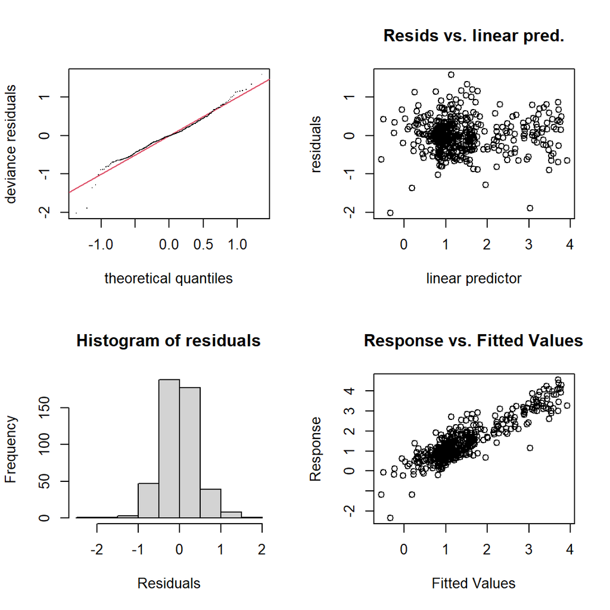

```
##
## Method: ML   Optimizer: outer newton
## full convergence after 29 iterations.
## Gradient range [-3.093999e-05,8.517954e-05]
## (score 318.1617 & scale 0.197512).
## eigenvalue range [-1.745541e-05,232.5662].
## Model rank =  354 / 354
##
## Basis dimension (k) checking results. Low p-value (k-index<1) may
## indicate that k is too low, especially if edf is close to k'.
##
##                                             k'      edf k-index p-value
## s(logDissAmmonia)                     9.00e+00 1.31e+00    1.04   0.765
## s(logDissOrthophos)                   9.00e+00 3.71e-05    1.00   0.530
## s(logDissNitrateNitrite)              9.00e+00 9.36e-01    0.96   0.190
## s(Temperature)                        9.00e+00 2.96e+00    0.95   0.115
## s(logConductivity):RegionsCentral     9.00e+00 1.82e+00    0.97   0.225
## s(logConductivity):RegionsConfluence  9.00e+00 3.40e-05    0.97   0.270
## s(logConductivity):RegionsNorth Delta 9.00e+00 9.87e-01    0.97   0.220
## s(logConductivity):RegionsSouth       9.00e+00 4.36e+00    0.97   0.180
## s(logConductivity):RegionsSuisun Bay  9.00e+00 1.53e-05    0.97   0.210
## s(Index)                              9.00e+00 3.84e-05    0.81  <2e-16 ***
## s(lagIndex)                           9.00e+00 3.84e-05    0.81  <2e-16 ***
## s(logSAC):RegionsCentral              9.00e+00 2.97e-05    0.88  <2e-16 ***
## s(logSAC):RegionsConfluence           9.00e+00 5.69e-05    0.88  <2e-16 ***
## s(logSAC):RegionsNorth Delta          9.00e+00 2.37e-05    0.88  <2e-16 ***
## s(logSAC):RegionsSouth                9.00e+00 1.53e-04    0.88   0.010 **
## s(logSAC):RegionsSuisun Bay           9.00e+00 2.63e-05    0.88   0.005 **
## s(logSJR):RegionsCentral              9.00e+00 7.76e-01    0.94   0.165
## s(logSJR):RegionsConfluence           9.00e+00 3.48e-05    0.94   0.095 .
## s(logSJR):RegionsNorth Delta          9.00e+00 8.90e-01    0.94   0.120
## s(logSJR):RegionsSouth                9.00e+00 5.92e-05    0.94   0.095 .
## s(logSJR):RegionsSuisun Bay           9.00e+00 8.00e-05    0.94   0.115
## s(EXPORT):RegionsCentral              9.00e+00 1.45e-04    0.86  <2e-16 ***
## s(EXPORT):RegionsConfluence           9.00e+00 6.13e-01    0.86  <2e-16 ***
## s(EXPORT):RegionsNorth Delta          9.00e+00 4.31e+00    0.86  <2e-16 ***
## s(EXPORT):RegionsSouth                9.00e+00 2.70e+00    0.86  <2e-16 ***
## s(EXPORT):RegionsSuisun Bay           9.00e+00 3.33e-01    0.86  <2e-16 ***
## s(laglogSAC_mo):RegionsCentral        9.00e+00 3.50e-05    0.94   0.130
## s(laglogSAC_mo):RegionsConfluence     9.00e+00 2.91e-05    0.94   0.065 .
## s(laglogSAC_mo):RegionsNorth Delta    9.00e+00 2.85e-05    0.94   0.075 .
## s(laglogSAC_mo):RegionsSouth          9.00e+00 1.72e-04    0.94   0.135
## s(laglogSAC_mo):RegionsSuisun Bay     9.00e+00 3.83e-05    0.94   0.070 .
## s(laglogSJR_mo):RegionsCentral        9.00e+00 4.59e-05    1.02   0.670
## s(laglogSJR_mo):RegionsConfluence     9.00e+00 4.00e-05    1.02   0.650
## s(laglogSJR_mo):RegionsNorth Delta    9.00e+00 7.59e-04    1.02   0.650
## s(laglogSJR_mo):RegionsSouth          9.00e+00 5.41e-05    1.02   0.645
## s(laglogSJR_mo):RegionsSuisun Bay     9.00e+00 6.66e-05    1.02   0.630
## s(laglogDissAmmonia_mo)               9.00e+00 1.77e+00    1.13   0.995
## s(laglogDissOrthophos_mo)             9.00e+00 2.47e-01    0.98   0.340
## s(laglogDissNitrateNitrite_mo)        9.00e+00 3.53e-05    0.97   0.275
## s(Month)                              1.00e+00 4.57e-07    0.84  <2e-16 ***
## ---
## Signif. codes:  0 '***' 0.001 '**' 0.01 '*' 0.05 '.' 0.1 ' ' 1
```

```r
gam.check(smr.1.test)
```

LogDissOrthophos, Index, lagIndex, laglogDissNitrateNitrite_mo, Month

### Plot Predictions

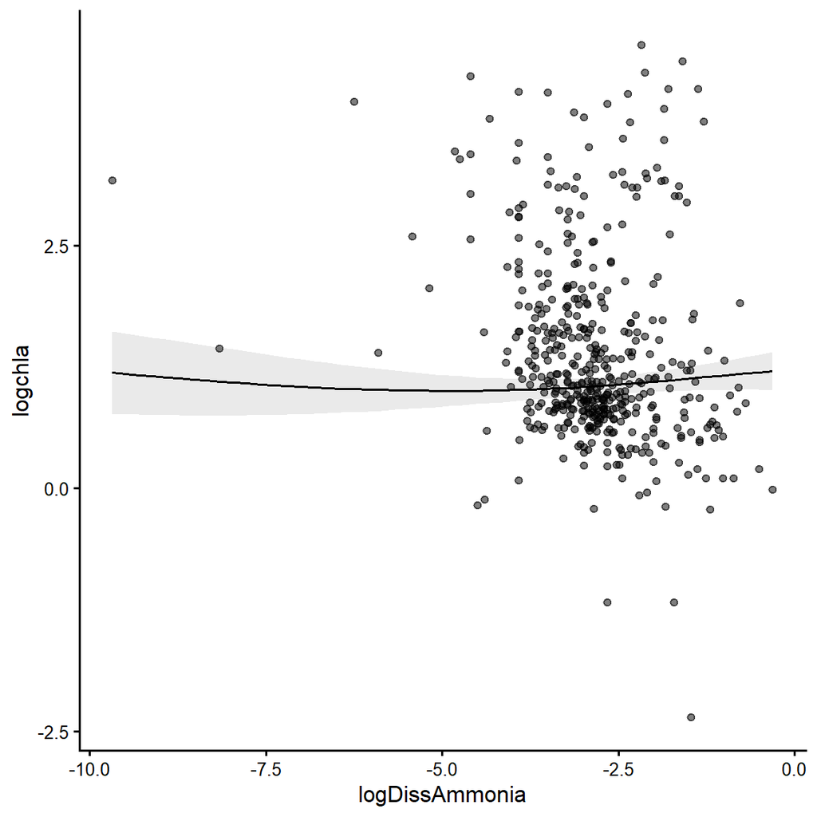

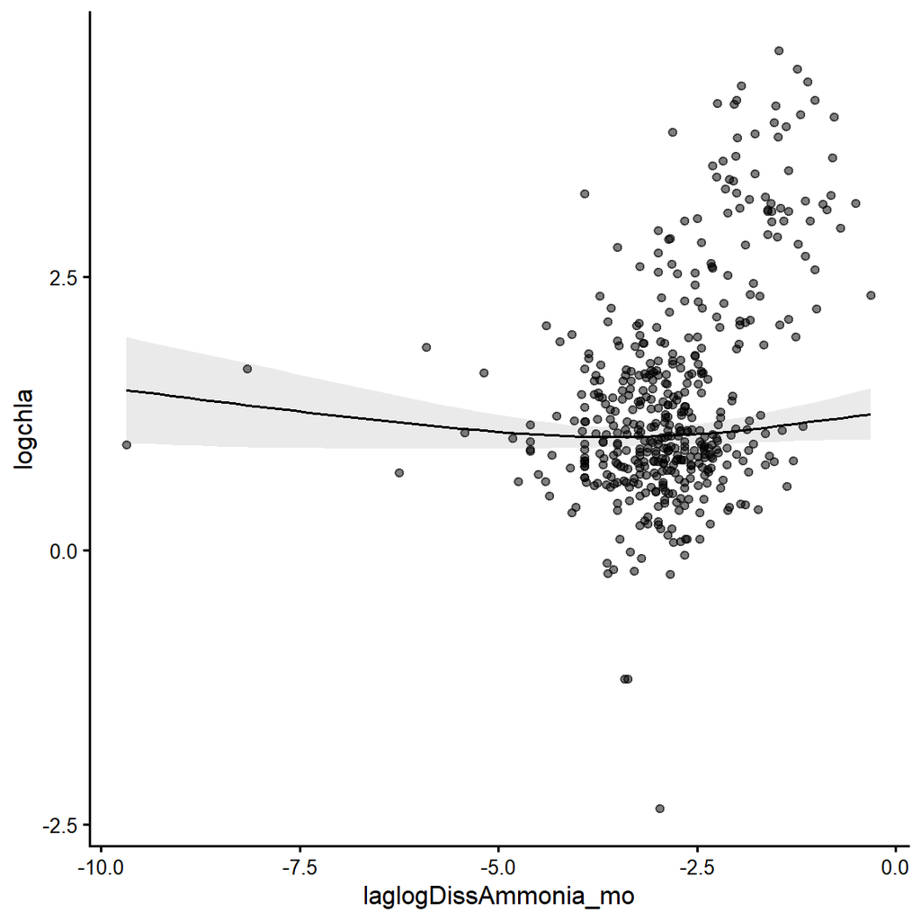

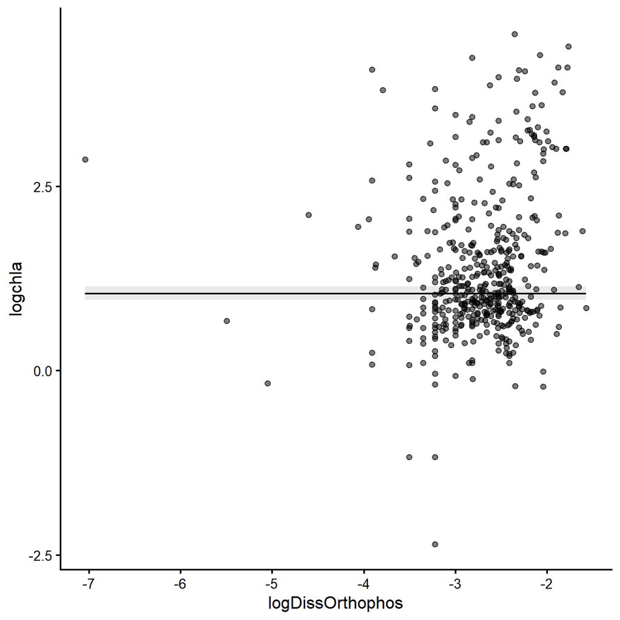

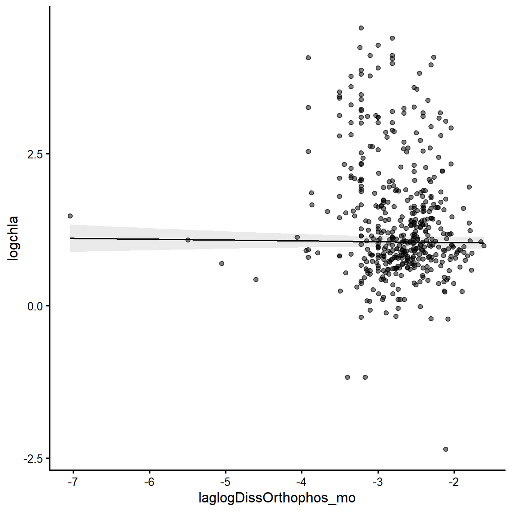

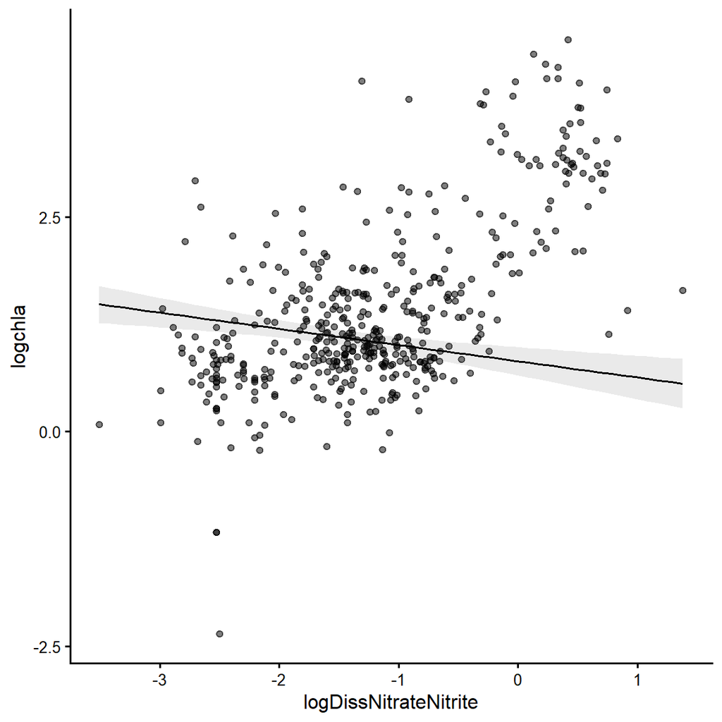

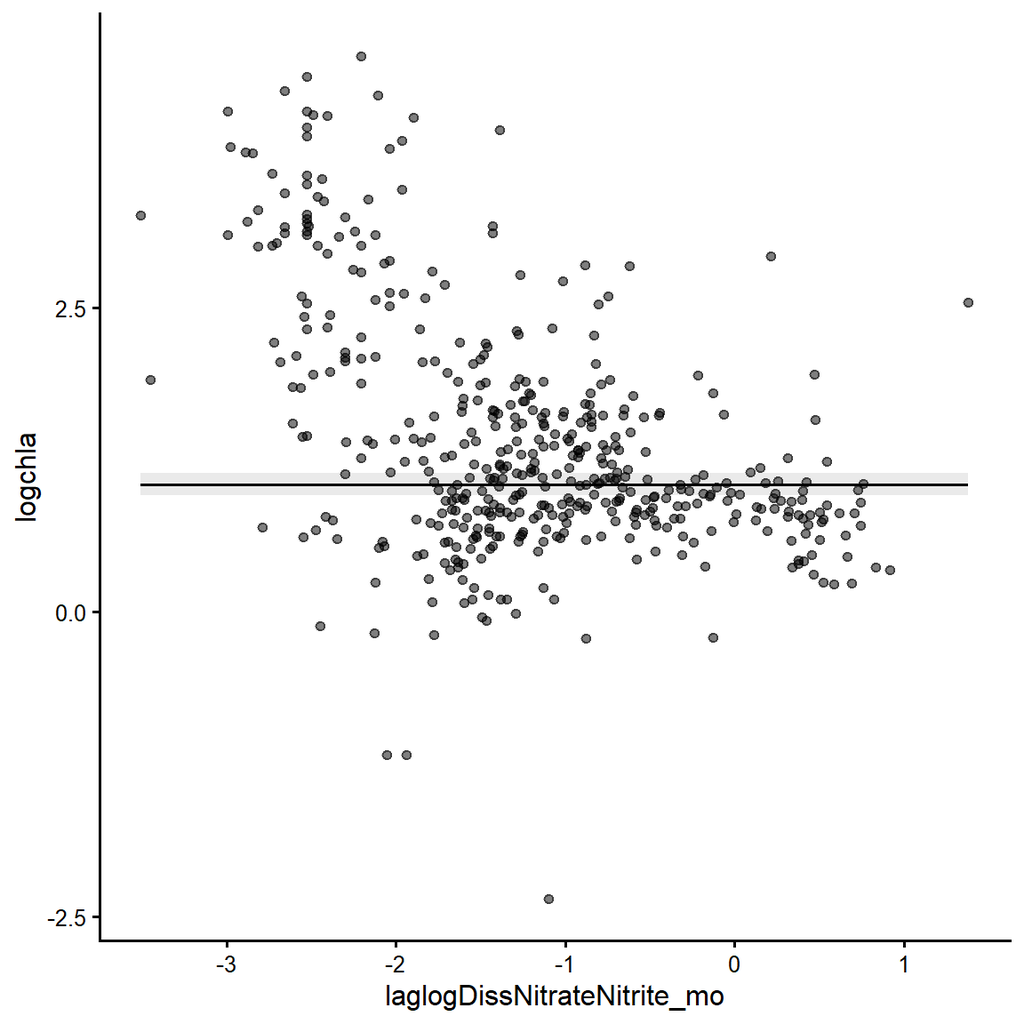

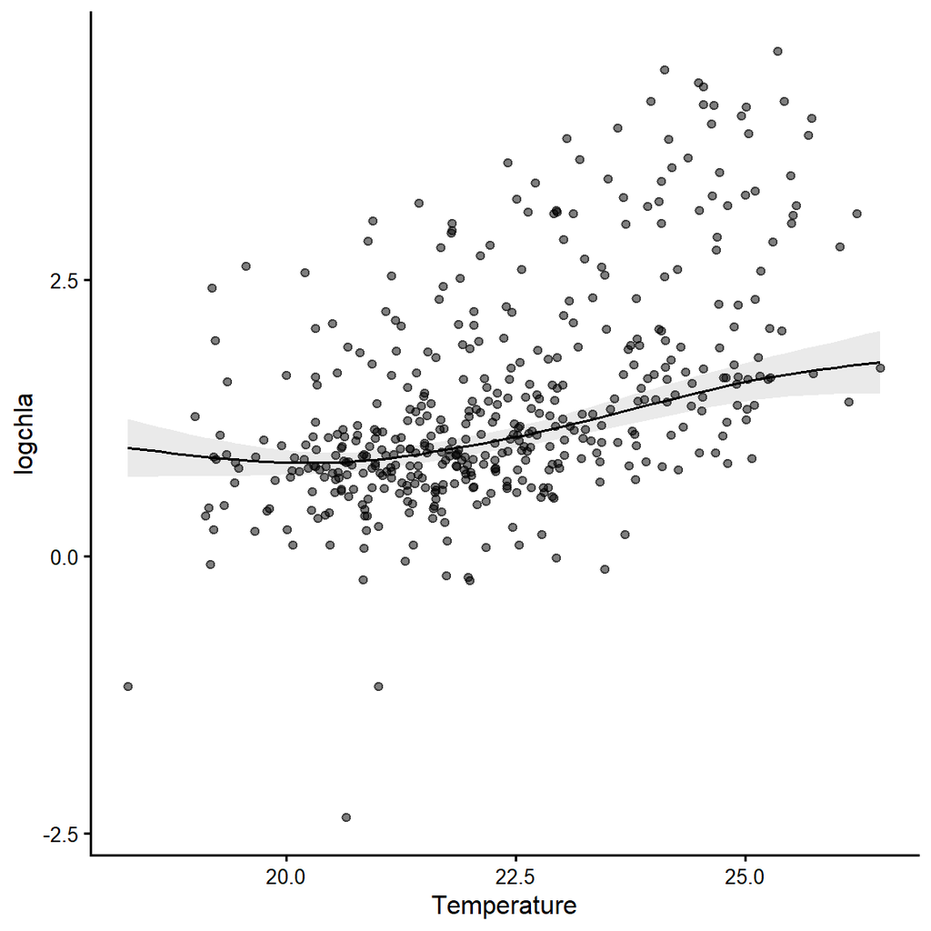

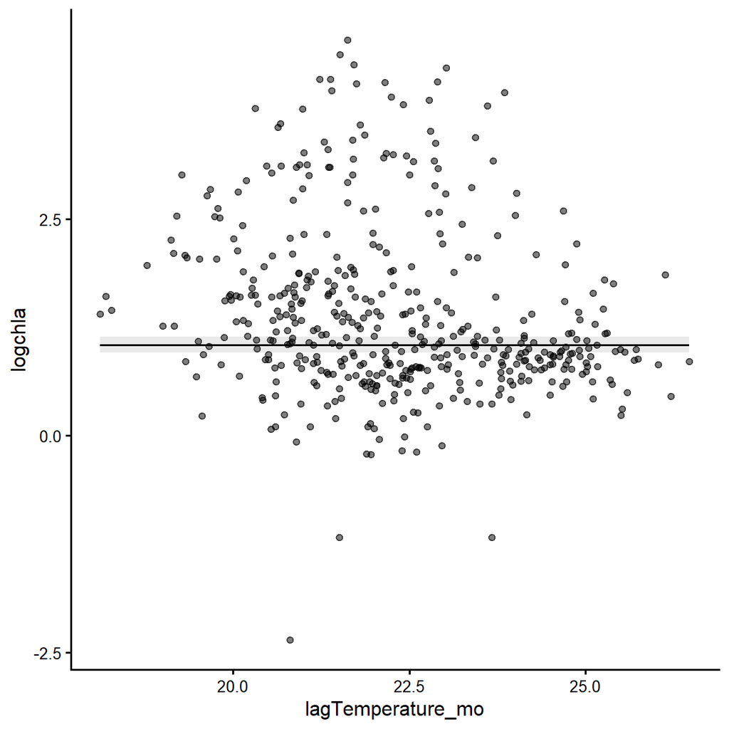

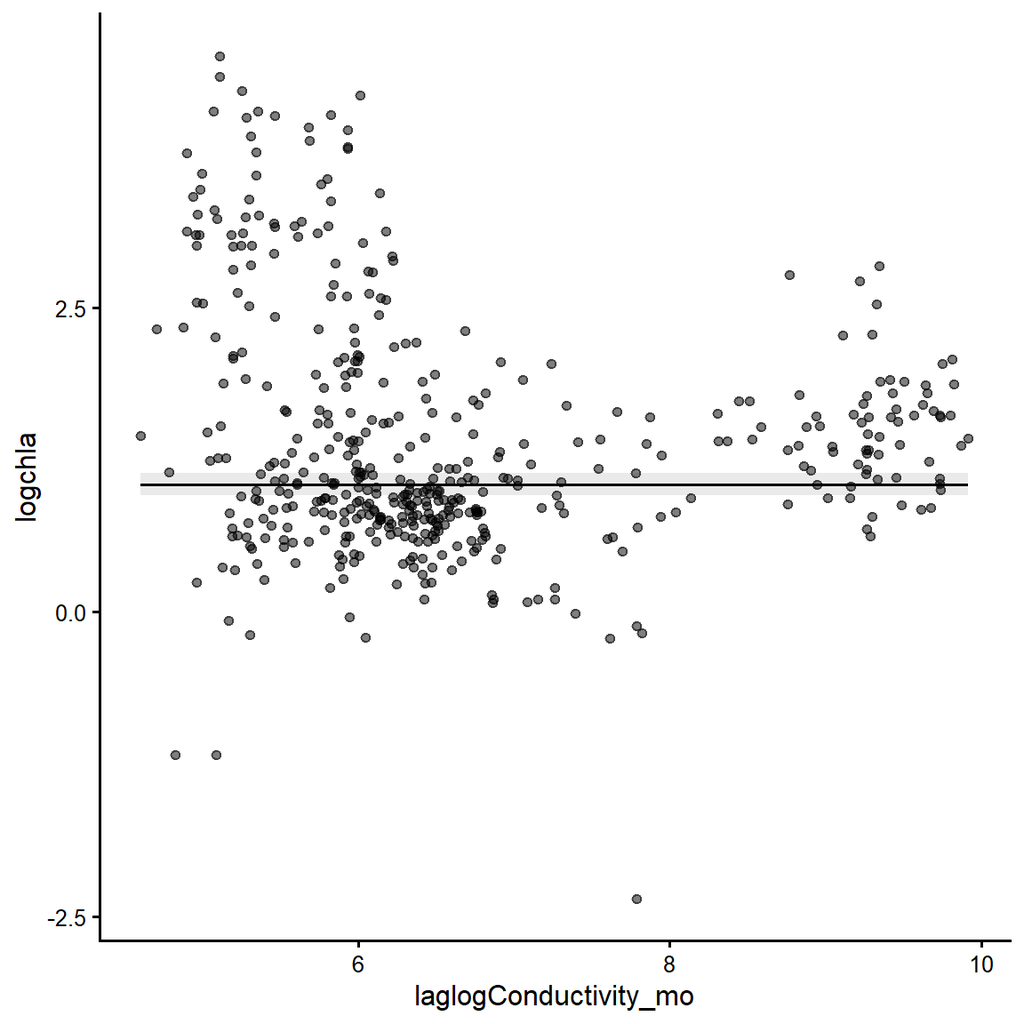

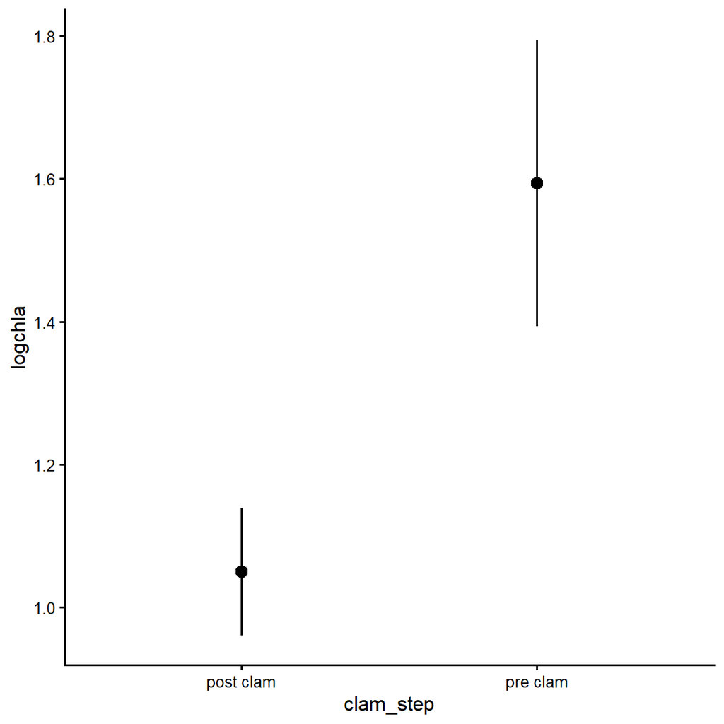

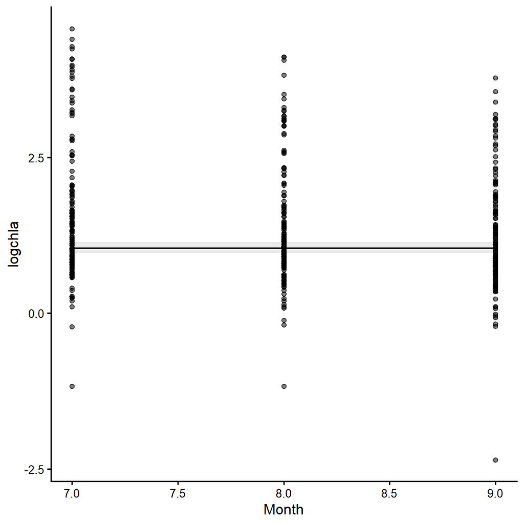

```r
c = c("logDissAmmonia","laglogDissAmmonia_mo","logDissOrthophos","laglogDissOrthophos_mo","logDissNitrateNitrite","laglogDissNitrateNitrite_mo","Temperature","lagTemperature_mo","laglogConductivity_mo","clam_step", "Month")
lapply(c, function(x) {
  plot_predictions(smr.1.test, x , points = .5) +
    theme_classic(base_size = 12)
})
```

Terms with regional interactions:

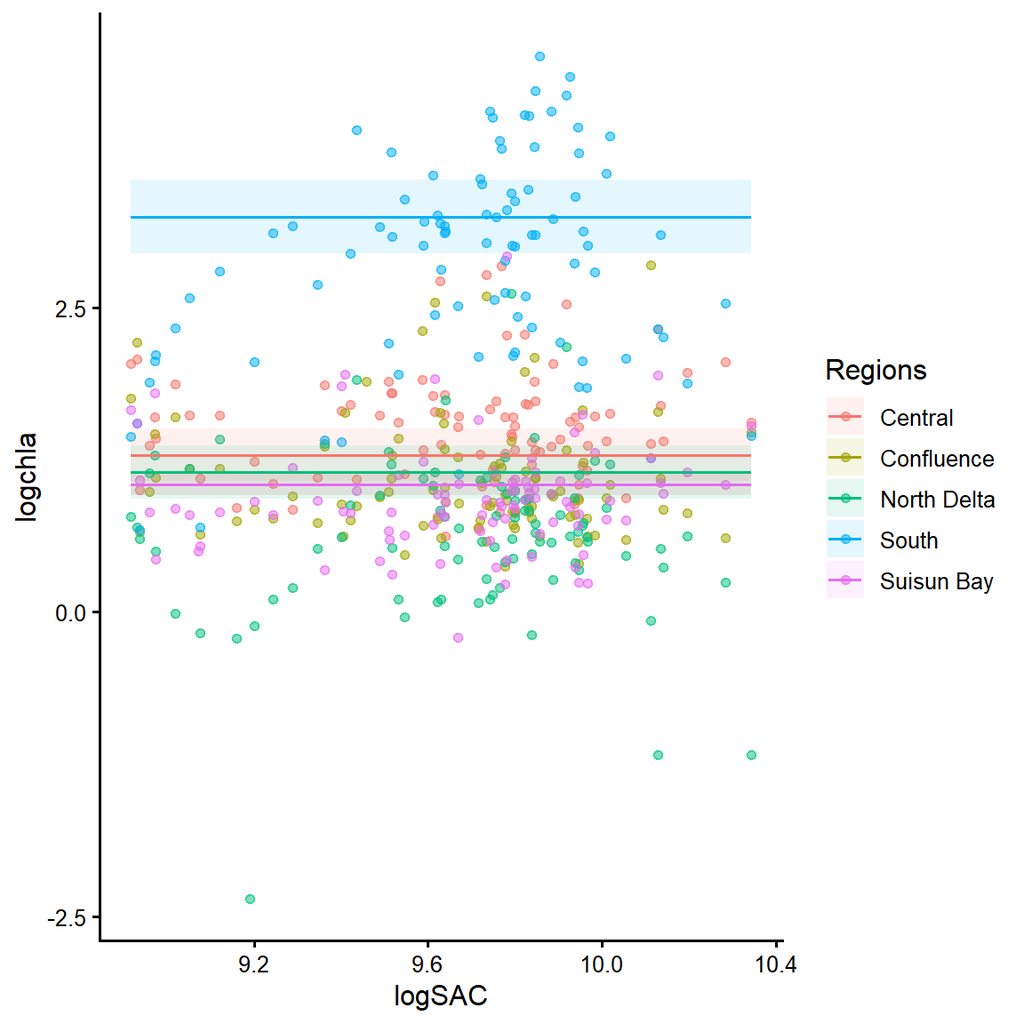

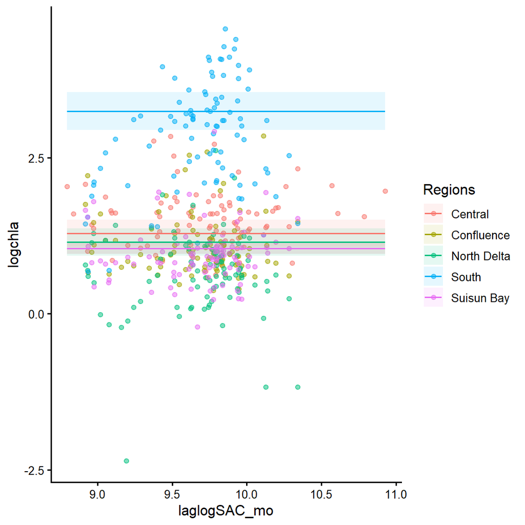

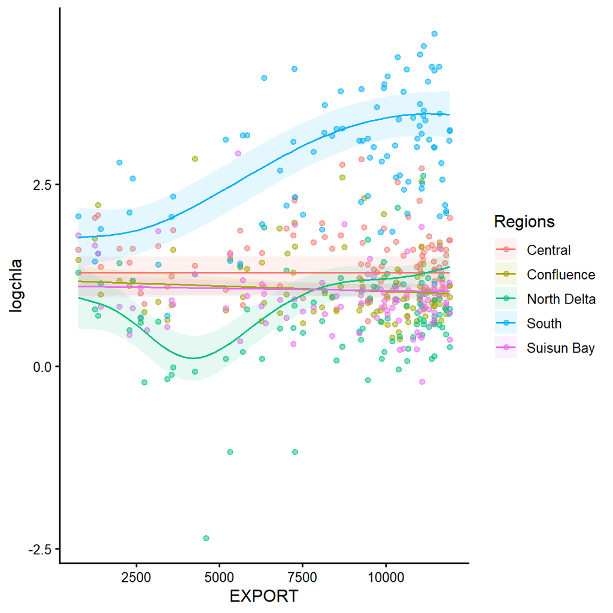

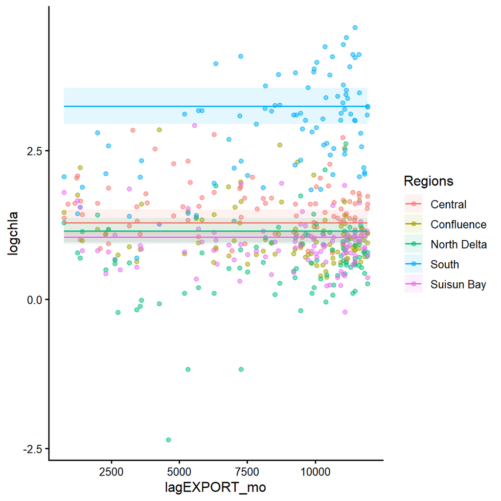

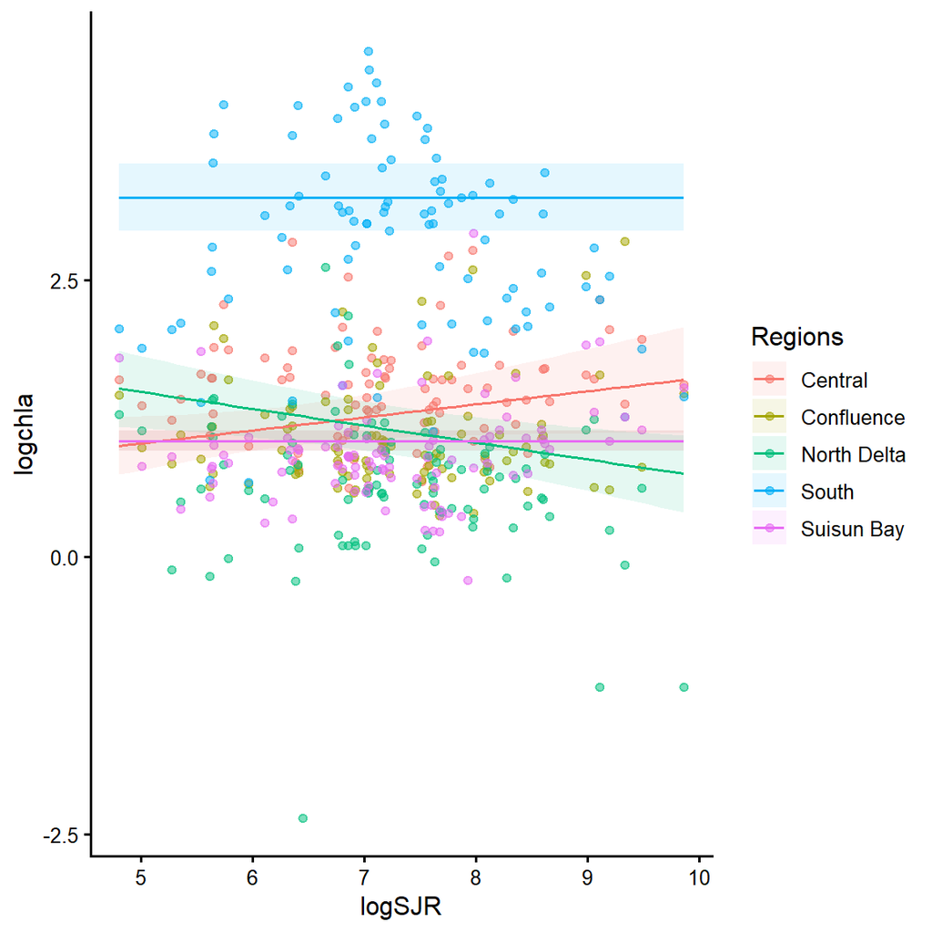

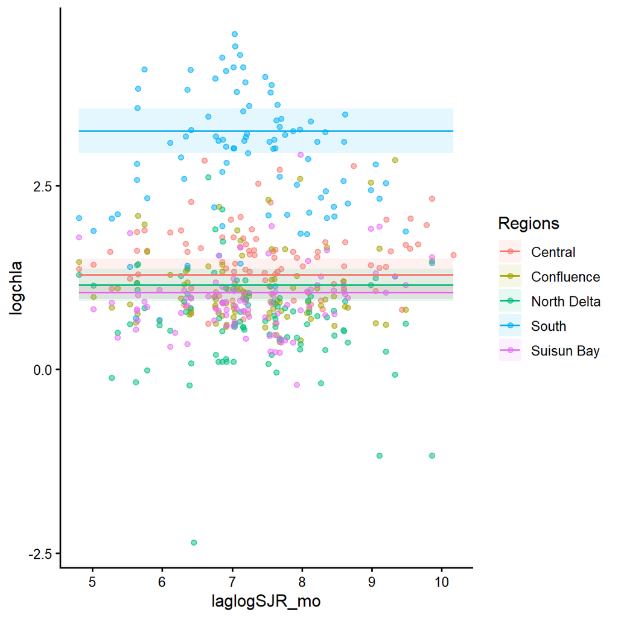

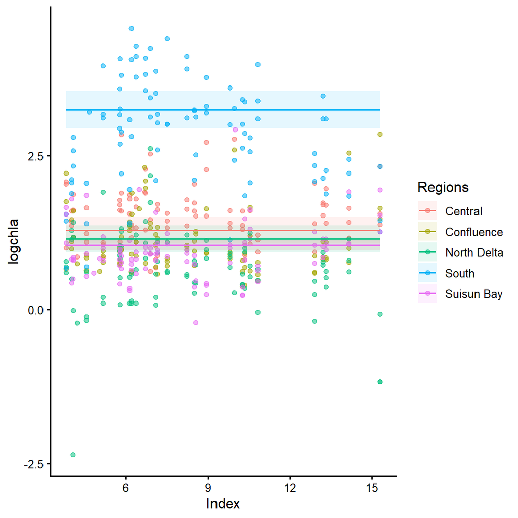

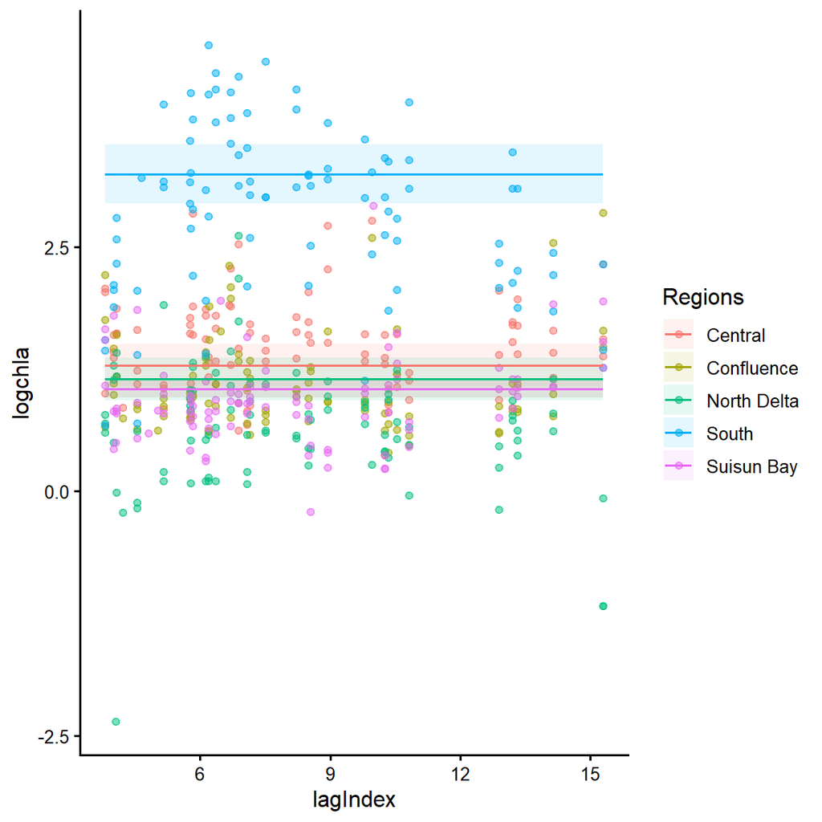

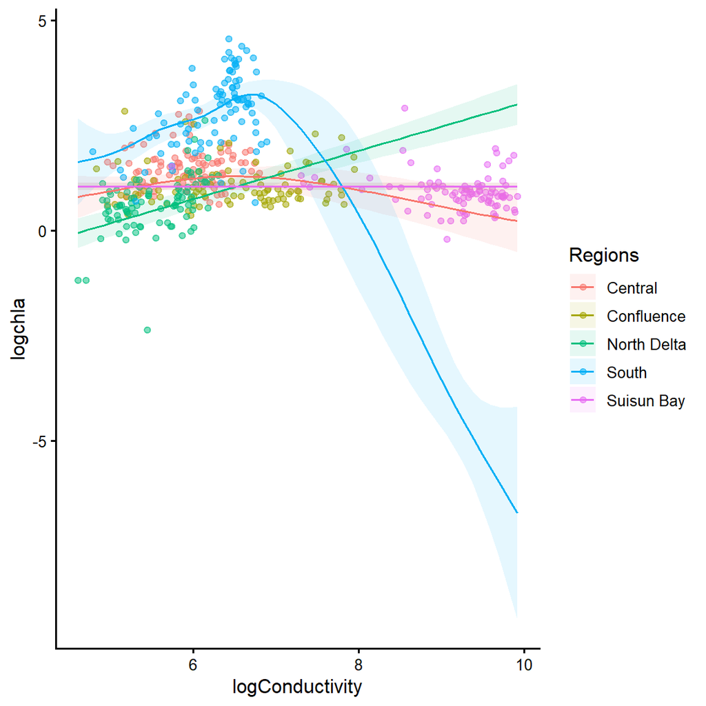

```r
c = c("logSAC", "laglogSAC_mo", "EXPORT","lagEXPORT_mo", "logSJR", "laglogSJR_mo", "Index","lagIndex","logConductivity")
lapply(c, function(x) {
    plot_predictions(smr.1.test, condition = c(x,"Regions"), points = 0.5) +
      theme_classic(base_size = 12)
})
```

## smr.2.test

Model 2: Summer Chla ~ s(logNH4) + s(logPO4) + s(log(NO2+NO3)) + s(temperature) + s(logconductivity) + Sac Valley index + previous year(Sac Valley index) + Pre/post-clam + s(lag(logNDOI)) + s(Region:log(NDOI)) + lag(logNH4) + s(lag(PO4)) + s(lag(logNO2+NO3)) + (1|Month)

```r
smr.2.test <- gam(logchla ~ s(logDissAmmonia) + s(logDissOrthophos) + s(logDissNitrateNitrite) + s(Temperature) + s(logConductivity, by=Regions) + s(Index) + s(lagIndex) + clam_step + s(logOUT) + s(logOUT, by = Regions) + s(laglogDissAmmonia_mo) + s(laglogDissOrthophos_mo)+ s(laglogDissNitrateNitrite_mo) + s(Month, bs="re"), data=smr, method = 'ML', select=TRUE)
```

### summary

```r
summary(smr.2.test)
```

```
##
## Family: gaussian
## Link function: identity
##
## Formula:
## logchla ~ s(logDissAmmonia) + s(logDissOrthophos) + s(logDissNitrateNitrite) +
##     s(Temperature) + s(logConductivity, by = Regions) + s(Index) +
##     s(lagIndex) + clam_step + s(logOUT) + s(logOUT, by = Regions) +
##     s(laglogDissAmmonia_mo) + s(laglogDissOrthophos_mo) + s(laglogDissNitrateNitrite_mo) +
##     s(Month, bs = "re")
##
## Parametric coefficients:
##                   Estimate Std. Error t value Pr(>|t|)
## (Intercept)        1.22729    0.03802  32.281  < 2e-16 ***
## clam_steppre clam  0.52777    0.11295   4.673 3.96e-06 ***
## ---
## Signif. codes:  0 '***' 0.001 '**' 0.01 '*' 0.05 '.' 0.1 ' ' 1
##
## Approximate significance of smooth terms:
##                                             edf Ref.df      F  p-value
## s(logDissAmmonia)                     2.129e-04      9  0.000 0.453174
## s(logDissOrthophos)                   1.696e+00      9  0.846 0.005482 **
## s(logDissNitrateNitrite)              7.518e-01      9  0.336 0.040856 *
## s(Temperature)                        2.822e+00      9  9.374  < 2e-16 ***
## s(logConductivity):RegionsCentral     8.073e-05      9  0.000 0.568712
## s(logConductivity):RegionsConfluence  4.697e-01      9  0.099 0.162446
## s(logConductivity):RegionsNorth Delta 3.876e+00      8  9.390  < 2e-16 ***
## s(logConductivity):RegionsSouth       4.084e+00      9 15.355  < 2e-16 ***
## s(logConductivity):RegionsSuisun Bay  8.151e-05      9  0.000 0.864527
## s(Index)                              1.911e+00      9  0.337 0.000253 ***
## s(lagIndex)                           1.911e+00      9  0.337 0.000253 ***
## s(logOUT)                             1.503e-01      9  0.020 0.256596
## s(logOUT):RegionsCentral              9.797e-05      9  0.000 0.925289
## s(logOUT):RegionsConfluence           1.271e-04      9  0.000 0.842447
## s(logOUT):RegionsNorth Delta          2.298e+00      9  1.268 0.001875 **
## s(logOUT):RegionsSouth                1.932e+00      9  1.053 0.002943 **
## s(logOUT):RegionsSuisun Bay           2.652e-04      9  0.000 0.394893
## s(laglogDissAmmonia_mo)               1.986e+00      9  0.790 0.013677 *
## s(laglogDissOrthophos_mo)             7.755e-01      9  0.379 0.033933 *
## s(laglogDissNitrateNitrite_mo)        8.606e-01      9  0.715 0.005280 **
## s(Month)                              1.619e-06      1  0.000 0.011099 *
## ---
## Signif. codes:  0 '***' 0.001 '**' 0.01 '*' 0.05 '.' 0.1 ' ' 1
##
## R-sq.(adj) =   0.77   Deviance explained = 78.4%
## -ML = 346.68  Scale est. = 0.22119   n = 465
```

### GAM Check

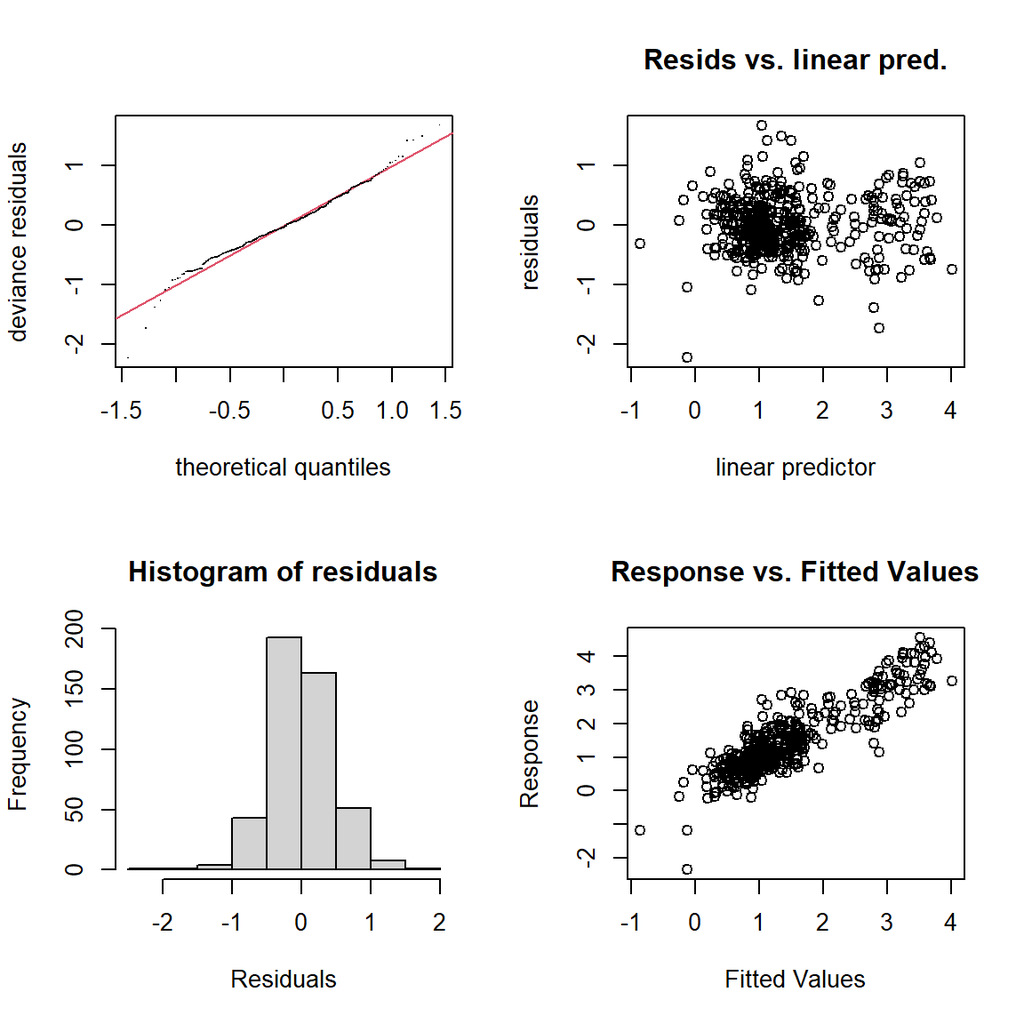

```
##
## Method: ML   Optimizer: outer newton
## full convergence after 22 iterations.
## Gradient range [-0.000677258,0.001280496]
## (score 346.6776 & scale 0.2211895).
## Hessian positive definite, eigenvalue range [7.094271e-06,232.5676].
## Model rank =  183 / 183
##
## Basis dimension (k) checking results. Low p-value (k-index<1) may
## indicate that k is too low, especially if edf is close to k'.
##
##                                             k'      edf k-index p-value
## s(logDissAmmonia)                     9.00e+00 2.13e-04    1.08   0.940
## s(logDissOrthophos)                   9.00e+00 1.70e+00    1.01   0.560
## s(logDissNitrateNitrite)              9.00e+00 7.52e-01    1.00   0.495
## s(Temperature)                        9.00e+00 2.82e+00    0.92   0.040 *
## s(logConductivity):RegionsCentral     9.00e+00 8.07e-05    0.98   0.355
## s(logConductivity):RegionsConfluence  9.00e+00 4.70e-01    0.98   0.385
## s(logConductivity):RegionsNorth Delta 9.00e+00 3.88e+00    0.98   0.310
## s(logConductivity):RegionsSouth       9.00e+00 4.08e+00    0.98   0.330
## s(logConductivity):RegionsSuisun Bay  9.00e+00 8.15e-05    0.98   0.315
## s(Index)                              9.00e+00 1.91e+00    0.83  <2e-16 ***
## s(lagIndex)                           9.00e+00 1.91e+00    0.83  <2e-16 ***
## s(logOUT)                             9.00e+00 1.50e-01    0.95   0.150
## s(logOUT):RegionsCentral              9.00e+00 9.80e-05    0.95   0.135
## s(logOUT):RegionsConfluence           9.00e+00 1.27e-04    0.95   0.095 .
## s(logOUT):RegionsNorth Delta          9.00e+00 2.30e+00    0.95   0.115
## s(logOUT):RegionsSouth                9.00e+00 1.93e+00    0.95   0.150
## s(logOUT):RegionsSuisun Bay           9.00e+00 2.65e-04    0.95   0.105
## s(laglogDissAmmonia_mo)               9.00e+00 1.99e+00    1.11   0.990
## s(laglogDissOrthophos_mo)             9.00e+00 7.75e-01    0.98   0.360
## s(laglogDissNitrateNitrite_mo)        9.00e+00 8.61e-01    0.96   0.155
## s(Month)                              1.00e+00 1.62e-06    0.80  <2e-16 ***
## ---
## Signif. codes:  0 '***' 0.001 '**' 0.01 '*' 0.05 '.' 0.1 ' ' 1
```

```r
gam.check(smr.2.test)
```

logDissAmmonia